# Logistic Regression & Non-linear Effects

## Preface

### R packages

In this practical, we use the R package **effects**. It can be installed by running the following syntax:

### Dataset

For this practical, we will use the **pbc** dataset from the package **survival**.

You can either load the **survival** package to get access to this dataset

or make a copy of this data

The **pbc** data contain (among others) the following variables:

```
'data.frame':   418 obs. of  8 variables:
 $ age    : num  58.8 56.4 70.1 54.7 38.1 ...
 $ sex    : Factor w/ 2 levels "m","f": 2 2 1 2 2 2 2 2 2 2 ...
 $ ascites: int  1 0 0 0 0 0 0 0 0 1 ...
 $ hepato : int  1 1 0 1 1 1 1 0 0 0 ...
 $ spiders: int  1 1 0 1 1 0 0 0 1 1 ...
 $ edema  : num  1 0 0.5 0.5 0 0 0 0 0 1 ...
 $ bili   : num  14.5 1.1 1.4 1.8 3.4 0.8 1 0.3 3.2 12.6 ...
 $ stage  : int  4 3 4 4 3 3 3 3 2 4 ...
```

## Fitting a Logistic Regression

We want to fit a logistic regression model for the outcome `spiders` using the covariates `age`, `sex`, `bili`, `stage` and `ascites`.

### Variable coding

#### Task 1

Are the variables coded correctly? If not, re-code them.

Three of the variables of interest are coded as integer.

#### Solution 1

The variables `ascites`, `spiders` and `stage` are coded as integer. Both `ascites` and `spiders` do only have two levels, therefore we *could* use them as they are:

```
   0    1 <NA>
 222   90  106
```

```
   0    1 <NA>
 288   24  106
```

`stage` has four levels and should be re-coded as a factor:

```
   1    2    3    4 <NA>
  21   92  155  144    6
```

#### Task 2

Fit the logistic model described above and get the model summary.

A logistic regression model is a GLM.

You need to specify the model `formula`, the `data` and the `family`.

#### Solution 2

```
Call:
glm(formula = spiders ~ age + sex + bili + stage + ascites, family = binomial(),
    data = pbc)

Deviance Residuals:
    Min       1Q   Median       3Q      Max
-1.7728  -0.7471  -0.5353   0.9351   2.3718

Coefficients:
            Estimate Std. Error z value Pr(>|z|)
(Intercept) -2.93568    1.36930  -2.144  0.03204 *
age         -0.02051    0.01410  -1.455  0.14577
sexf         1.21276    0.57295   2.117  0.03429 *
bili         0.09867    0.03109   3.174  0.00151 **
stage2       0.65103    1.10384   0.590  0.55533
stage3       1.37092    1.06306   1.290  0.19719
stage4       2.27858    1.06739   2.135  0.03278 *
ascites1     0.26188    0.53826   0.487  0.62659
---
Signif. codes:  0 '***' 0.001 '**' 0.01 '*' 0.05 '.' 0.1 ' ' 1

(Dispersion parameter for binomial family taken to be 1)

    Null deviance: 374.88  on 311  degrees of freedom
Residual deviance: 321.27  on 304  degrees of freedom
  (106 observations deleted due to missingness)
AIC: 337.27

Number of Fisher Scoring iterations: 5
```

#### Task 3

Investigate the output of the model summary.

- Were there missing values in the data? What happened with those cases?
- What is the interpretation of the coefficient for `bili` in this model?
- What is the interpretation of the coefficients for `stage`?

#### Solution 3

**Missing values:**  
In the lower part of the output of the model summary we can read:

```
[...]
     Null deviance: 374.88  on 311  degrees of freedom
 Residual deviance: 321.27  on 304  degrees of freedom
   (106 observations deleted due to missingness)
 AIC: 337.27
 [...]
```

There were 106 cases with missing values. These were excluded from the analysis.

**Interpretation fo the effect of `bili`:**

```
Coefficients:
             Estimate Std. Error z value Pr(>|z|)
 [...]
 bili         0.09867    0.03109   3.174  0.00151 **
 [...]
```

With every 1 unite increase of `bili` the expected log odds of having `spiders`, i.e., $\log\left(\frac{P(\texttt{spiders = 1})}{1 - P(\texttt{spiders=1})}\right)$, increases by $\beta_{\texttt{bili}} = 0.099$ (while all other covariates in the model are kept constant).

This means that the odds ratio of `bili` is $\exp(\beta_{\texttt{bili}}) = \exp(0.099) = 1.104$.

**Interpretation of the effect(s) of `stage`:**

```
Coefficients:
             Estimate Std. Error z value Pr(>|z|)
 [...]
 stage2       0.65103    1.10384   0.590  0.55533
 stage3       1.37092    1.06306   1.290  0.19719
 stage4       2.27858    1.06739   2.135  0.03278 *
 [...]
```

A patient with `stage = 2` has a $\beta_{\texttt{stage2}} = 0.651$ higher log odds to have `spiders` than a patient with `stage = 1` (and the same values for all other covariates).  
The odds ratio of `stage = 2` is $\exp(\beta_{\texttt{stage2}}) = \exp(0.651) = 1.918$.

Patients with `stage = 3` or `stage = 4` have a $\beta_{\texttt{stage3}} = 1.371$ and $\beta_{\texttt{stage4}} = 2.279$ higher log odds to have `spiders` than a patient with `stage = 1` (who has the same values for all other covariates).  
The corresponding odds ratios of `stage = 3` and `stage = 4` are $\exp(\beta_{\texttt{stage3}}) = \exp(1.371) = 3.939$ and $\exp(\beta_{\texttt{stage4}}) = \exp(2.279) = 9.763$, respectively.

### Comparing Models

We would like to know if the variable `stage` has a significant/relevant contribution to the model.

#### Task 1

How can we determine this? Does the output of the `summary()` give us an answer?

#### Solution 1

Since `stage` is a factor with >2 levels, multiple dummy variables are used in the model. To answer the question whether `stage` has a significant/relevant contribution we need to consider all three dummy variables simultaneously.

Therefore, we need to compare `mod1` with the model in which `stage` was removed.

#### Task 2

Re-fit `mod1` without `stage` (but give it a different name).

#### Solution 2

**Note:** The function `update()` allows us to update models or formulas.

- To update a model, specify the new values for those arguments that change.
- To update a formula, we can use the `.` to say ‘as it was’ and only add the change.

#### Task 3

- Are the models `mod1` and `mod1b` nested or not?
- Which method can we use to compare them?
- Perform this comparison and interpret the result.

#### Solution 3

The models are nested. `mod1b` is a specific case of `mod1` for which $\beta_{\texttt{stage2}} = \beta_{\texttt{stage3}} = \beta_{\texttt{stage4}} = 0$

To compare nested models, we can use a likelihood ratio test:

```
Analysis of Deviance Table

Model 1: spiders ~ age + sex + bili + stage + ascites
Model 2: spiders ~ age + sex + bili + ascites
  Resid. Df Resid. Dev Df Deviance Pr(>Chi)
1       304     321.27
2       307     342.65 -3   -21.38 8.78e-05 ***
---
Signif. codes:  0 '***' 0.001 '**' 0.01 '*' 0.05 '.' 0.1 ' ' 1
```

The small p-value indicates that the observed difference in residual deviance between the two models would be very unlikely to observe if `mod1b` was the correct model.

Hence, the model with `stage` fits the data better.

## Non-linear effects

We now want to investigate if the continuous variables have non-linear effect.

### Task 1

To do this, use a natural cubic splines with three degrees of freedom.

Use the function `ns()` from the package `splines`.

### Solution 1

```
Call:
glm(formula = spiders ~ ns(age, df = 3) + sex + ns(bili, df = 3) +
    stage + ascites, family = binomial(), data = pbc)

Deviance Residuals:
    Min       1Q   Median       3Q      Max
-1.5599  -0.7723  -0.4592   0.9689   2.4957

Coefficients:
                  Estimate Std. Error z value Pr(>|z|)
(Intercept)        -4.9676     1.4427  -3.443 0.000575 ***
ns(age, df = 3)1   -0.5062     0.6187  -0.818 0.413253
ns(age, df = 3)2   -0.2193     1.8429  -0.119 0.905292
ns(age, df = 3)3   -0.4484     1.0426  -0.430 0.667141
sexf                1.4727     0.5869   2.509 0.012098 *
ns(bili, df = 3)1   1.9401     0.8638   2.246 0.024699 *
ns(bili, df = 3)2   4.5549     1.2426   3.666 0.000247 ***
ns(bili, df = 3)3   2.2240     1.1900   1.869 0.061642 .
stage2              0.3438     1.1180   0.308 0.758447
stage3              0.9110     1.0815   0.842 0.399585
stage4              1.6438     1.0919   1.506 0.132190
ascites1            0.2423     0.5394   0.449 0.653314
---
Signif. codes:  0 '***' 0.001 '**' 0.01 '*' 0.05 '.' 0.1 ' ' 1

(Dispersion parameter for binomial family taken to be 1)

    Null deviance: 374.88  on 311  degrees of freedom
Residual deviance: 310.91  on 300  degrees of freedom
  (106 observations deleted due to missingness)
AIC: 334.91

Number of Fisher Scoring iterations: 5
```

### Task 2

What is the interpretation of the regression coefficients for `bili` in `mod2`?

### Solution 2

The coefficients tell us how much each of the basis functions of the splines have been scaled. They do not have a direct meaningful clinical interpretation.

### Visualization

To visualize the resulting non-linear fit, we can use an effect plot.

The idea is to obtain fitted values for a specific set of cases, which vary in the value of the covariate of interest, but have constant values for all other covariates.

The R package **effects** can help us in creating such plots:

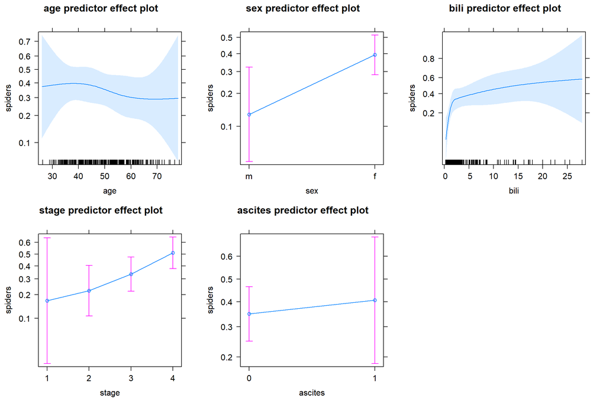

From the **effects** package documentation:

> […] the vertical axis is in linear predictor scale, which is the log-odds or logit for this logistic regression example, but the vertical axis labels are in mean (probability) scale, so the tick-marks are not equally spaced

The plot for `age`, for example, shows us the estimated probability (and corresponding 95% confidence band) for having `spiders` for any given `age` while the other variables have been fixed to the population mean.

For a more information about the **effects** package and its functions, please refer to the reference manual and vignettes available at https://CRAN.R-project.org/package=effects.

### Task 3

The effect plots show that the effect of `age` is quite linear, but that the effect of `bili` is indeed non-linear.

Confirm that the non-linear effect for `age` is not needed, i.e., does not fit the data better than the corresponding model with a linear effect of `age`.

Re-fit the model and replace the spline for `age` with just `age` to compare the model fit.

For the comparison, use the `AIC()` or `BIC()`.

### Solution 3

When comparing models with regards to the effect of a variable that is modeled using a spline, models are usually not nested (except in specific cases). therefore, we will use here the information criteria to compare `mod2` and `mod2b`:

```
      df      BIC
mod2  12 379.8257
mod2b 10 368.5101
```

We see that the smaller (less degrees of freedom / parameters) model has the lower BIC. This confirms that the spline specification for `age` is not necessary.

### Task 4

The non-linear association for `bili` resemples the shape of the logarithmic function.

Investigate if we can replace the spline for `bili` with the (natural) logarithm.

- using information criteria
- visually

For the visual comparison, the function `predictorEffect(predictor = "bili", mod = <name of model>)` may be useful if you want to show the effect plot for the variable `bili` only.

### Solution 4

```
      df      BIC
mod2b 10 368.5101
mod2c  8 358.4755
```

The BIC shows that the model with `log(bili)` has better model fit.

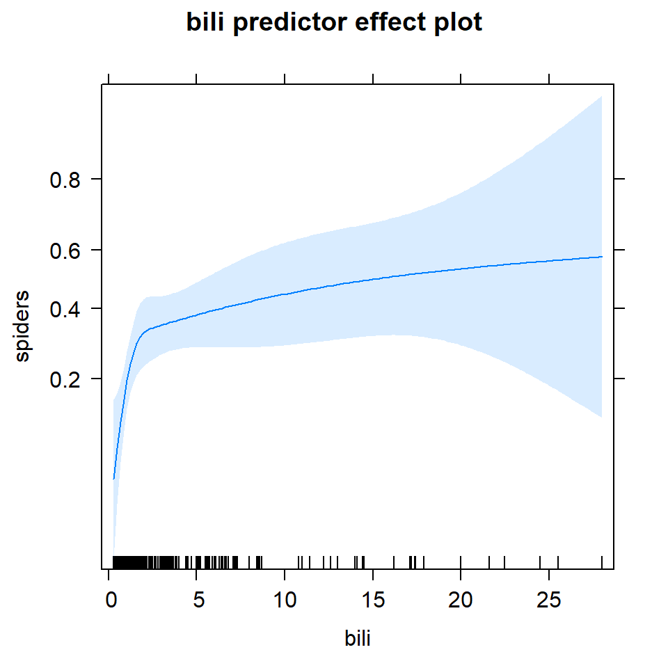

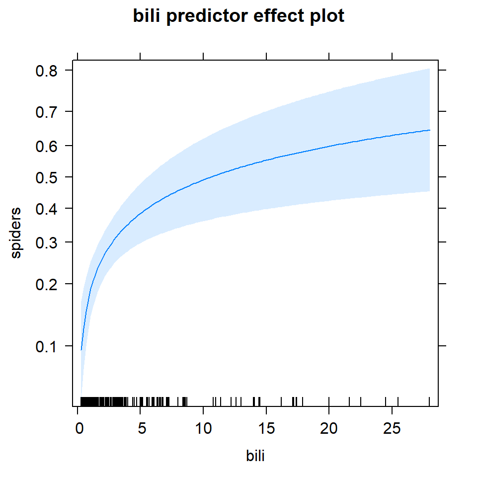

## Addtitional

### Extra Task:

How does the model interpretation change if we use the ordinal version of `stage`?

```
Call:
glm(formula = spiders ~ age + sex + chol + bili + stage_ord +
    ascites, family = binomial(), data = pbc)

Deviance Residuals:
    Min       1Q   Median       3Q      Max
-1.6892  -0.7688  -0.5030   0.9416   2.2690

Coefficients:
              Estimate Std. Error z value Pr(>|z|)
(Intercept) -5.947e+00  2.685e+02  -0.022   0.9823
age         -1.149e-02  1.518e-02  -0.757   0.4491
sexf         1.274e+00  5.857e-01   2.175   0.0297 *
chol        -1.710e-04  6.779e-04  -0.252   0.8009
bili         8.606e-02  3.580e-02   2.404   0.0162 *
stage_ord.L  1.171e+01  7.204e+02   0.016   0.9870
stage_ord.Q -7.194e+00  5.369e+02  -0.013   0.9893
stage_ord.C  3.197e+00  2.401e+02   0.013   0.9894
ascites1     9.736e-02  5.765e-01   0.169   0.8659
---
Signif. codes:  0 '***' 0.001 '**' 0.01 '*' 0.05 '.' 0.1 ' ' 1

(Dispersion parameter for binomial family taken to be 1)

    Null deviance: 341.38  on 283  degrees of freedom
Residual deviance: 289.81  on 275  degrees of freedom
  (134 observations deleted due to missingness)
AIC: 307.81

Number of Fisher Scoring iterations: 16
```

### Investigate the problem with stage

```
        0  1 <NA>
  1    15  1    5
  2    58  9   25
  3    90 30   35
  4    59 50   35
  <NA>  0  0    6
```

```
     0  1
  1 13  0
  2 54  7
  3 85 30
  4 50 45
```

```
[1] "1" "2" "3" "4"
```

```
[1] "4" "1" "2" "3"
```

```
[1] "4" "3" "2" "1"
```

```
Call:
glm(formula = spiders ~ age + sex + chol + bili + stage_rev +
    ascites, family = binomial(), data = pbc)

Deviance Residuals:
    Min       1Q   Median       3Q      Max
-1.6892  -0.7688  -0.5030   0.9416   2.2690

Coefficients:
              Estimate Std. Error z value Pr(>|z|)
(Intercept) -9.726e-01  1.098e+00  -0.885 0.375931
age         -1.149e-02  1.518e-02  -0.757 0.449141
sexf         1.274e+00  5.857e-01   2.175 0.029666 *
chol        -1.710e-04  6.779e-04  -0.252 0.800890
bili         8.606e-02  3.580e-02   2.404 0.016230 *
stage_rev3  -9.030e-01  3.320e-01  -2.720 0.006534 **
stage_rev2  -1.852e+00  4.769e-01  -3.883 0.000103 ***
stage_rev1  -1.714e+01  1.074e+03  -0.016 0.987263
ascites1     9.736e-02  5.765e-01   0.169 0.865879
---
Signif. codes:  0 '***' 0.001 '**' 0.01 '*' 0.05 '.' 0.1 ' ' 1

(Dispersion parameter for binomial family taken to be 1)

    Null deviance: 341.38  on 283  degrees of freedom
Residual deviance: 289.81  on 275  degrees of freedom
  (134 observations deleted due to missingness)
AIC: 307.81

Number of Fisher Scoring iterations: 16
```

practice `update()`

© Nicole Erler